# Introducción a R

Christian Urcuqui

24 de septiembre de 2018

## Introducción

[figure not shown]

En este notebook se presentará una introducción a la programación en R para su uso en proyectos de ciencia de datos.

### Motivación

Debido a los grandes volumenes de información que se presentan hoy en día la forma de analizar los datos ha estado cambiando. Algunas personas han mencionado que “Los datos son el petróleo del siglo xxi”.

La ciencia de datos a partir de sus técnicas (por ejemplo, estadísticas, visuales, econométricas y de aprendizaje de máquina) han permitido descubrir y explotar la información.

Antiguamente, los investigadores solían publicar sus resultados en prestigiosas revistas y la implementación de sus descubrimientos en software tomaba mucho tiempo.

Actualmente, los investigadores y la industria han mejorado sus métodos en conjunto con la implementación de software, estos resultados ahora se encuentran en sitios web de fácil acceso (en muchos casos con licencia open source)

### R

R es un entorno y un lenguaje para computación estadística y gráfica desarrollado en Bell Labs, un proyecto que surge de la implemententación del software libre S. Nace en el depto. de estadística de la Universidad de Auckland, Nueva Zelanda (Ross Ihaka and Robert Gentleman) en el año de 1993.

Una solución open source para análisis de datos soportado por varias comunidades científicas en todo el mundo.

R tiene muchas ventajas frente a los otros software comerciales de alto costo para uso de análisis de datos, estas son:

- Es una tecnología gratuita a diferencia de otros software comerciales de altos costos.
- Tiene comunidades muy activas, casi semanalmente se proponen nuevos paquetes estadísticos y actualizaciones, lo cual a llevado a los sistemas comerciales a integrar R.
- Es más fácil la automatización ya que se pueden desarrollar scripts (líneas de código con un propósito especifico) que permiten ejecutar el análisis varias veces.
- Leer casi cualquier tipo de datos (.txt, .csv, .dat), también, existen paquetes que permiten leer información de archivos JSON, Excel, STATA, SAS. E incluso utilizar datos de sitios web y de sistemas de base de datos (Por ejemplo, MySQL y, PostgresSQL)

## Descarga e instalación de R

Como hemos mencionado, R es un proyecto **open source**, su descarga se puede encontrar en el sitio web de Comprehensive R Archive Network (CRAN):

http://cran.r-project.org.

De la anterior página podemos descargar los archivos binarios para instalación en sistemas opertivos Linux, Mac OS X, y Windows.

## Trabajando con R

R es un lenguaje interpretado, es decir, que podemos digitar un comando a la vez con R o se puede ejecutar un archivo que contenga las líneas de código y el interprete ejecutará linea por linea .

Muchos de los datos y variables son almacenadas en memoria durante una sesión. Nosotros podemos guardar una sesión con la finalidad de conservar nuestro trabajo para futuras sesiones.

R utiliza el símbolo **<-** para detonar una asignación, a diferencia del típico = utilizado en muchos otros lenguajes de programación, a continuación, verá un ejemplo de una asignación a la variable *x*, a esta variable se le asigna un vector de 5 valores a través de la función rnorm (el llamado a funciones lo veremos más adelante en este mismo notebook).

```
x <- rnorm(5)
```

Por favor escriba el anterior ejemplo y ejecutelo en el próximo espacio.

*Ejercicio 1*

```r
## Escriba el ejemplo en el siguiente espacio (1 línea de código) ##
x <- rnorm(5)
# --------------------------- #
x
```

```
## [1] -0.6630933  0.4544930 -0.2541547 -0.6901018 -0.2260937
```

Los comentarios sobre el código podemos agregarlos con *#*.

Ahora, si deseamos obtener mayor información sobre una función podemos utilizar la opción de ayuda con R a través de *?*, ejecute el siguiente ejemplo en su consola.

```
?rnorm
```

Como hemos mencionado, la aplicación de la función rnorm nos dio un vector de cinco valores. Ahora si deseamos crear un vector con unos valores especificos y asignarlo a una variable, debemos proceder a digitar la función *c* seguido de los valores que queremos tener dentro de *()* y cada valor separado por *,*, por favor, digite el siguiente ejemplo en el espacio de código.

```
vector <- c(1,4,5,6)
```

*Ejercicio 2*

```r
# Digite el ejemplo del vector en el siguiente espacio (1 línea de código)
vector <- c(1,4,5,6)
# --------------------------- #
vector
```

```
## [1] 1 4 5 6
```

Hemos creado un vector de cuatro valores y lo hemos asignado a la variable *vector*.

Procesamos a un tercer ejercicio, vamos a crear una tabla a través de la asignación de vectores, utilizaremos unas funciones predefinidas en R para estadística descriptiva y vamos a crear un gráfico. Por favor, cree dos vectores para las columnas **Age (mo.)** y **Weight (kg.)**.

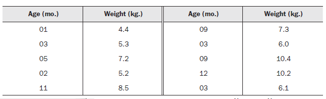

*Ejercicio 3*

```r
# Por favor escriba los dos vectores en el siguiente espacio (2 lineas de código)
age <- c(01,03,5,2,11,9,3,9,12,3)
weight <- c(4.4,5.3,7.2,5.2,8.5,7.3,6.0,10.4,10.2,6.1)
# --------------------------- #
print("Vector de Age")
```

```
## [1] "Vector de Age"
```

```r
age
```

```
##  [1]  1  3  5  2 11  9  3  9 12  3
```

```r
print("Vector de Weight")
```

```
## [1] "Vector de Weight"
```

```r
weight
```

```
##  [1]  4.4  5.3  7.2  5.2  8.5  7.3  6.0 10.4 10.2  6.1
```

```r
print("Desviación estandar")
```

```
## [1] "Desviación estandar"
```

```r
sd(weight)
```

```
## [1] 2.077498
```

```r
print("Correlación entre age y weight")
```

```
## [1] "Correlación entre age y weight"
```

```r
cor(age, weight)
```

```
## [1] 0.9075655
```

```r
print("gráfico de age versus weight")
```

```
## [1] "gráfico de age versus weight"
```

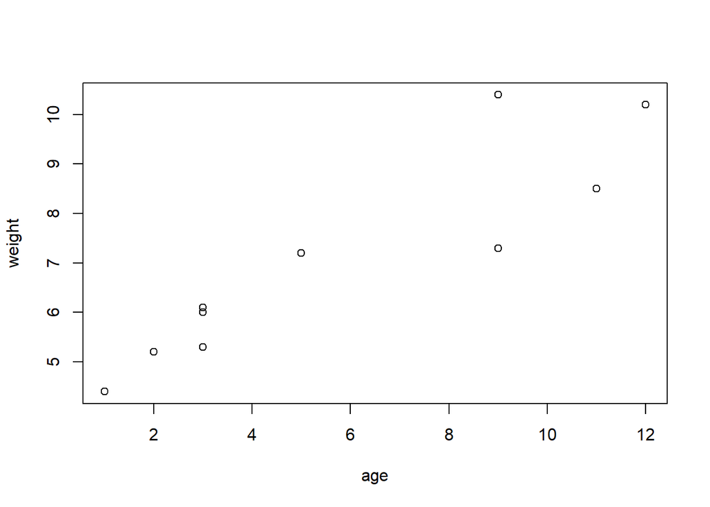

```r
plot(age, weight)
```

## Paquetes

Existen numerosas funciones de R en distintos paquetes que nos pueden facilitar la vida. La instalación de un paquete se realiza a través de:

```
install.packages("nombre del paquete")
```

Como hemos mencionado, constantemente las comunidades lanzan nuevas versiones de sus paquetes ya sea para incorporar nuevas funcionalidades o para corregir algún error; si deseamos estar en la ultima versión podemos utilizar el siguiente comando:

```
update.packages()
```

Para cargar el paquete que necesitamos utilizar en nuestro entorno de trabajo debe utilizar el siguiente comando en conjunto con el nombre del paquete

```
library(gclus)
```

Para este siguiente ejercicio escriba las lineas de código que permitan instalar los paquetes “tidyverse” y “nycflights13”, luego cargue ambos al entorno de trabajo.

Es probable que el paquete ya se encuentre instalado.

*Ejercicio 4*

```r
# Escriba el código que permita instalar y cargar los dos paquetes (cuatro líneas)
#install.packages("tidyverse")
library("tidyverse")
#install.packages("nycflights13")
library("nycflights13")
# --------------------------- #
```

## Funciones

Cada paquete trae consigo una serie de funciones y la única forma de acceder a estas utilidades es cargan paquete a paquete a nuestro entorno de trabajo, la estructura general de función puede interpretarse de la siguiente manera:

```
nombre_funcion(parametro1 = valor1, parametro2 = valor2, ...)
```

Para nuestro próximo ejercicio utilizaremos la función *seq*, por favor utilice la opción de ayuda en la consola y luego en el siguiente cuadro de código digite una línea que utilice la función para crear un vector de valores del 1 hasta el 10.

*Ejercicio 5*

```r
# Escriba el código que utilice la funcion seq y cree un vector de valores del 1 hasta el 10 (1 línea de código)
vector <- seq(1,10)
# --------------------------- #
vector
```

```
##  [1]  1  2  3  4  5  6  7  8  9 10
```

## Exploración de datos

Vamos a utilizar un conjunto de datos ( **dataset** ) de los vuelos realiados en la ciudad de Nueva York en 2013. Vamos a ejecutar el siguiente código que nos permitirá ver nuestro data.frame

```r
# La siguiente línea de código especifica que vamos a utilizar "flights" del paquete nycflights13, esto se realiza con la finalidad que no se presenten problemas si hay más variables "flights" en nuestro entorno de trabajo.
nycflights13::flights
```

```
## # A tibble: 336,776 x 19
##     year month   day dep_time sched_dep_time dep_delay arr_time
##    <int> <int> <int>    <int>          <int>     <dbl>    <int>
##  1  2013     1     1      517            515         2      830
##  2  2013     1     1      533            529         4      850
##  3  2013     1     1      542            540         2      923
##  4  2013     1     1      544            545        -1     1004
##  5  2013     1     1      554            600        -6      812
##  6  2013     1     1      554            558        -4      740
##  7  2013     1     1      555            600        -5      913
##  8  2013     1     1      557            600        -3      709
##  9  2013     1     1      557            600        -3      838
## 10  2013     1     1      558            600        -2      753
## # ... with 336,766 more rows, and 12 more variables: sched_arr_time <int>,
## #   arr_delay <dbl>, carrier <chr>, flight <int>, tailnum <chr>,
## #   origin <chr>, dest <chr>, air_time <dbl>, distance <dbl>, hour <dbl>,
## #   minute <dbl>, time_hour <dttm>
```

```r
flights
```

```
## # A tibble: 336,776 x 19
##     year month   day dep_time sched_dep_time dep_delay arr_time
##    <int> <int> <int>    <int>          <int>     <dbl>    <int>
##  1  2013     1     1      517            515         2      830
##  2  2013     1     1      533            529         4      850
##  3  2013     1     1      542            540         2      923
##  4  2013     1     1      544            545        -1     1004
##  5  2013     1     1      554            600        -6      812
##  6  2013     1     1      554            558        -4      740
##  7  2013     1     1      555            600        -5      913
##  8  2013     1     1      557            600        -3      709
##  9  2013     1     1      557            600        -3      838
## 10  2013     1     1      558            600        -2      753
## # ... with 336,766 more rows, and 12 more variables: sched_arr_time <int>,
## #   arr_delay <dbl>, carrier <chr>, flight <int>, tailnum <chr>,
## #   origin <chr>, dest <chr>, air_time <dbl>, distance <dbl>, hour <dbl>,
## #   minute <dbl>, time_hour <dttm>
```

Con la finalidad que podamos tener una primera idea de nuestros datos, vamos a utilizar la función str, en primer lugar, escriba la ayuda de *?str* y obtenga más información de esta.

Ahora digite la función str sobre el objeto flights.

*Ejercicio 6*

```r
# Escriba el código que utilice la funcion str en el objeto flights (1 línea de código)
str(flights)
```

```
## Classes 'tbl_df', 'tbl' and 'data.frame':    336776 obs. of  19 variables:
##  $ year          : int  2013 2013 2013 2013 2013 2013 2013 2013 2013 2013 ...
##  $ month         : int  1 1 1 1 1 1 1 1 1 1 ...
##  $ day           : int  1 1 1 1 1 1 1 1 1 1 ...
##  $ dep_time      : int  517 533 542 544 554 554 555 557 557 558 ...
##  $ sched_dep_time: int  515 529 540 545 600 558 600 600 600 600 ...
##  $ dep_delay     : num  2 4 2 -1 -6 -4 -5 -3 -3 -2 ...
##  $ arr_time      : int  830 850 923 1004 812 740 913 709 838 753 ...
##  $ sched_arr_time: int  819 830 850 1022 837 728 854 723 846 745 ...
##  $ arr_delay     : num  11 20 33 -18 -25 12 19 -14 -8 8 ...
##  $ carrier       : chr  "UA" "UA" "AA" "B6" ...
##  $ flight        : int  1545 1714 1141 725 461 1696 507 5708 79 301 ...
##  $ tailnum       : chr  "N14228" "N24211" "N619AA" "N804JB" ...
##  $ origin        : chr  "EWR" "LGA" "JFK" "JFK" ...
##  $ dest          : chr  "IAH" "IAH" "MIA" "BQN" ...
##  $ air_time      : num  227 227 160 183 116 150 158 53 140 138 ...
##  $ distance      : num  1400 1416 1089 1576 762 ...
##  $ hour          : num  5 5 5 5 6 5 6 6 6 6 ...
##  $ minute        : num  15 29 40 45 0 58 0 0 0 0 ...
##  $ time_hour     : POSIXct, format: "2013-01-01 05:00:00" "2013-01-01 05:00:00" ...
```

```r
# --------------------------- #
```

- ¿Que puede inferir a través de la anterior función?
- Observe la cantidad de registros y variables
- observe los tipos de variables

Flights es un tipo de estructura en R conocida como data.frame. Si deseamos conocer el tipo de objeto con el cual estamos trabajando podemos obtener este tipo de información a través de la función *class()*. Digite el siguiente código en su consola de comandos.

```
class(flights)
```

Ahora, también podemos ver la información de nuestro data.frame como si fuera una hoja de trabajo en Excel. Utilice el siguiente código en su consola de comandos de RStudio.

```
View(flights)
```

Vamos a utilizar otras funciones y operaciones en R que nos permitan filtrar y hacer operaciones en los datos. A continuación, se muestra una tabla con la lista de operaciones tanto aritméticas como lógicas que se pueden realizar entre los objetos de R.

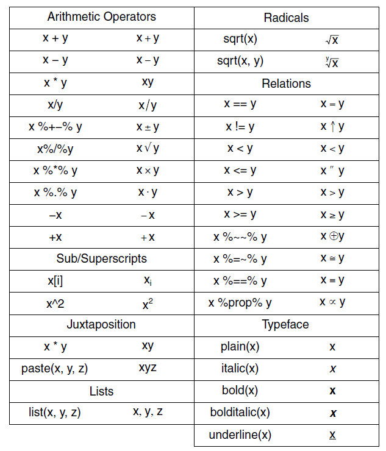

Hagamos unas operaciones básicas, nosotros podemos utilizar R como una especie de “calculadora”" (muy parecido a la operación entre celdas en Excel). En el siguiente cuadro de código hay unas variables númericas con valores ya asignados con el fin que usted pueda realizar las siguientes operaciones:

- x + y
- x * y
- -x
- sqrt(x)
- x == y
- x != y

*Ejercicio 7*

```r
#Ejecute las siguientes tres líneas de código para crear las variables
x = c(1, 2, 4, 7, 9, 0)
y = 4
z = c(0.5, 2, 3, 5, 1, 0)

# Escriba en el siguiente espacio la operación suma entre "x" y "y", y asígnelo a resultado_suma (1 línea de código)
resultado_suma <- x + y
# Escriba en el siguiente espacio la operación multiplicación entre "x" y "z", y asígnelo a resultado_multiplicacion (1 línea de código)
resultado_multiplicacion <- x * y
# Escriba en el siguiente espacio la operación multiplicación negativa a "z", y asígnelo a resultado_negativo (1 línea de código)
resultado_negativo <- -z
# Escriba en el siguiente espacio la operación de raíz cuadrada "y", y asígnelo a resultado_raiz (1 línea de código)
resultado_raiz <- sqrt(y)
# Escriba en el siguiente espacio la operación lógica de igualdad entre "x" y "z", y asígnelo a resultado_igualdad (1 línea de código)
resultado_igualdad <- x == z
# Escriba en el siguiente espacio la operación lógica de diferencia entre "x" y "y", y asígnelo a resultado_igualdad (1 línea de código)
resultado_diferencia <- x != y

# --------------------------- #

# Ahora ejecute las siguientes líneas de código que le permitirán observar los resultados de sus operaciones.

print("Resultado Suma")
```

```
## [1] "Resultado Suma"
```

```r
resultado_suma
```

```
## [1]  5  6  8 11 13  4
```

```r
print("Resultado multiplicación")
```

```
## [1] "Resultado multiplicación"
```

```r
resultado_multiplicacion
```

```
## [1]  4  8 16 28 36  0
```

```r
print("Resultado negativo")
```

```
## [1] "Resultado negativo"
```

```r
resultado_negativo
```

```
## [1] -0.5 -2.0 -3.0 -5.0 -1.0  0.0
```

```r
print("Resultado raíz cuadrada")
```

```
## [1] "Resultado raíz cuadrada"
```

```r
resultado_raiz
```

```
## [1] 2
```

```r
print("Resultado de operación lógica: igualdad")
```

```
## [1] "Resultado de operación lógica: igualdad"
```

```r
resultado_igualdad
```

```
## [1] FALSE  TRUE FALSE FALSE FALSE  TRUE
```

```r
print("Resultado de operación lógica: diferencia")
```

```
## [1] "Resultado de operación lógica: diferencia"
```

```r
resultado_diferencia
```

```
## [1]  TRUE  TRUE FALSE  TRUE  TRUE  TRUE
```

Ahora, exploremos la función *filter()*, esta función nos permite obtener un subconjunto de un observaciones de un conjunto más grande basado en los parámetros que le suministremos, vea el siguiente ejemplo.

```
filter(flights,  carrier == "UA")
```

La anterior línea de código nos permite obtener todos los vuelos realizados por una sola aerolínea (para nuestro caso aquella abreviada con “UA”).

En la siguiente tabla puede observar la sintaxis para las operaciones lógicas en R.

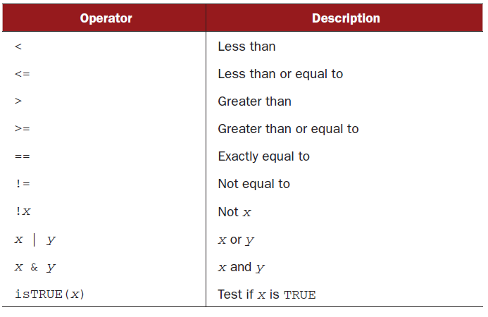

Nosotros podemos realizar varias operaciones lógicas enlazadas entre sí, por ejemplo:

```
filter(flights,  carrier == "B6" & distance <= 1500)
```

*Ejercicio 8*

```r
# Escriba en el siguiente espacio el filtro que permita obtener el subconjunto de vuelos (1 línea de código)
filter(flights, carrier== "AA" & (distance >= 1300 || distance <= 1800))
```

```
## # A tibble: 32,729 x 19
##     year month   day dep_time sched_dep_time dep_delay arr_time
##    <int> <int> <int>    <int>          <int>     <dbl>    <int>
##  1  2013     1     1      542            540         2      923
##  2  2013     1     1      558            600        -2      753
##  3  2013     1     1      559            600        -1      941
##  4  2013     1     1      606            610        -4      858
##  5  2013     1     1      623            610        13      920
##  6  2013     1     1      628            630        -2     1137
##  7  2013     1     1      629            630        -1      824
##  8  2013     1     1      635            635         0     1028
##  9  2013     1     1      656            700        -4      854
## 10  2013     1     1      656            659        -3      949
## # ... with 32,719 more rows, and 12 more variables: sched_arr_time <int>,
## #   arr_delay <dbl>, carrier <chr>, flight <int>, tailnum <chr>,
## #   origin <chr>, dest <chr>, air_time <dbl>, distance <dbl>, hour <dbl>,
## #   minute <dbl>, time_hour <dttm>
```

```r
# --------------------------- #
```

## Cargar archivos y bases de datos

R tienen la capacidad de cargar conjuntos de información en distintos formatos a nuestro entorno de trabajo. En el siguiente ejemplo veremos distintas formas de cargar archivos .csv y de otro tipo a través de comandos y del mismo RStudio, es muy importante conocer previamente el formato del archivo antes de cargarlo (por ejemplo, si los datos vienen separados por “;”, “,” y " “).

*Cargar archivos con RStudio*

En la sección de “environment”" podemos encontrar una opción “import Dataset” que nos abrirá unas opciones cargar los archivos los distintos tipos de archivos.

[figure not shown]

El anterior proceso es simplemente una abstracción de unos pasos que podemos realizar también a través de código en R, debemos tener cuidado con el separador, el tipo de archivo y conocer cuál es la función para cargarlo. A continuación, veremos cómo llamar a la función que nos permitirá abrir el buscador de archivos de nuestro sistema operativo.

```
file.choose()
```

Existen distintas funciones para cargar los archivos, por ejemplo:

- read.csv. Carga un archivo csv con separador “,”
- read.csv2. Carga un archivo csv con separador “;”
- read.delim. Carga un archivo con separador “”

Ahora, podemos integrar la función que nos da la opción para buscar el archivo en nuestro sistema y luego la encargada de cargarlo en nuestro entorno de trabajo.

```
read.csv2(file.choose())
```

Para el siguiente ejercicio cargue el archivo “parks.csv” y asignelo a una variable “df”.

*Ejercicio 9*

```r
# Escriba en el siguiente espacio el código que permita cargar el archivo parks.csv (1 línea de código)
df <- read.csv(file.choose())
# --------------------------- #
```

### Base de datos

Debido a la amplia gama de tecnologías de base de datos y a la importancia de procesar la mayor cantidad de información; es importante conocer los mecanismos (interfaces) con los cuales podamos integrar los distintos sistemas de información con R, ya que será el medio con el que podremos consultar y procesar los datos que serán luego utilizados en las actividades de la ciencia de datos.

#### MySQL

[figure not shown]

MYSQL es un sistema de gestión de base de datos relacional. Una de las tecnologías de mayor acogida en el soluciones web (por ejemplo, Joomla, Wordpress y Drupal).

Existen diversas interfaces de programación de aplicaciones que permiten el acceso a MySQL a distintos lenguajes de programación de programación, por ejemplo, C, C++, Python, Java y R.

Para la interacción de R y MySQL es necesario contar el paquete RMySQL en nuestro entorno de trabajo de R. Es importante tener previamente instalado el sistema de base de datos MySQL en nuestro equipo (por ejemplo, MySQL WorkBench). https://dev.mysql.com/downloads

A continuación, se enuncian algunos comandos a tener en cuenta para la configuración y acceso de un usuario a través del paquete RMySQL.

Existen distintas formas para crear un usuario en el MySQL workbench, para nuestro caso dejaremos un ejemplo de un script en SQL para la creación de un usuario con privilegios sobre un SCHEMA

```
CREATE USER 'username'@'localhost' IDENTIFIED BY 'SomethingDifficult';
GRANT SELECT, INSERT, UPDATE, DELETE, EXECUTE, SHOW VIEW ON database_name.* TO 'username'@'localhost';
```

Es importante que el tipo de autenticación sea tipo “Standard”, para lograr esto se puede digitar el siguiente script en SQL

```
ALTER USER 'username'@'localhost' IDENTIFIED WITH mysql_native_password BY 'SomethingDifficult';
```

### Paquetes para MySQL

Instalación de paquetes necesarios para el desarrollo de las sesiones

Cargar los paquetes

```r
library(RMySQL)
```

Vamos a conectarnos a través de R a la base de datos MySQL, para ello será necesario utilizar los métodos de RMySQL para definir los datos de nuestra cuenta y contraseña.

```r
# definición de la variable para el password
# dbname es el nombre de la base de datos creada en el sistema de base de datos MySQL
# host es el parámetro que define la dirección donde se encuentra hospedada la base de datos, para nuestro caso será en nuestro equipo local "localhost"
localuserpassword <- "SomethingDifficult"
#dbConnect es el método que nos permite conectarnos a la base de datos MySQL
#?dbConnect
storiesDb <- dbConnect(MySQL(), user='username', password=localuserpassword, dbname='sakila', host='localhost')

# La siguiente linea despliega las tablas de la base de datos cargada
dbListTables(storiesDb)
```

```
##  [1] "actor"                      "actor_info"
##  [3] "address"                    "category"
##  [5] "city"                       "country"
##  [7] "customer"                   "customer_list"
##  [9] "film"                       "film_actor"
## [11] "film_category"              "film_list"
## [13] "film_text"                  "inventory"
## [15] "language"                   "nicer_but_slower_film_list"
## [17] "payment"                    "rental"
## [19] "sales_by_film_category"     "sales_by_store"
## [21] "staff"                      "staff_list"
## [23] "store"
```

```r
# Vamos ahora a pasar la base de datos cargada a un data.frame,< el parámetro name define el nombre de la tabla a procesar
actor_df <- dbReadTable(conn = storiesDb, name = 'actor')
head(actor_df)
```

```
##   actor_id first_name    last_name         last_update
## 1        1   PENELOPE      GUINESS 2006-02-15 04:34:33
## 2        2       NICK     WAHLBERG 2006-02-15 04:34:33
## 3        3         ED        CHASE 2006-02-15 04:34:33
## 4        4   JENNIFER        DAVIS 2006-02-15 04:34:33
## 5        5     JOHNNY LOLLOBRIGIDA 2006-02-15 04:34:33
## 6        6      BETTE    NICHOLSON 2006-02-15 04:34:33
```

```r
# dbDisconnect es el método que nos permite terminar la conexión con la base de datos
#?dbDisconnect
dbDisconnect(storiesDb )
```

```
## [1] TRUE
```

## Referencias

- Kabacoff, R. (2015). R IN ACTION: Data analysis and graphics with R
- Wickham, H., & Grolemund, G. (2016). R for Data Science.